# Practical Machine Learning - Course Project

Carlos Cunha

November 21, 2015

# Objectives

This report was created for **Practical Machine Learning Course** project of the Johns Hopkins University (Bloomberg School of Public Health) Data Science Specialization on Coursera.org, and it aims to present all steps taken to predict in which way a series of execise were performed by subjects - data and definition used herein can be found at **Human Activity Recognition** (HAR) web page ([here](http://groupware.les.inf.puc-rio.br/har)).

To facilitate the understanding and reproducibility, all files were copied to [this](https://github.com/ceacunha/PMLProject) *GitHub repository*. In the repo, one will find:

- **data directory**: used to archive data files used for training (originaly from [here](https://d396qusza40orc.cloudfront.net/predmachlearn/pml-training.csv)) and test (originaly from [here](https://d396qusza40orc.cloudfront.net/predmachlearn/pml-testing.csv)) of machine learning algorithms;
- **output directory**: used to archive resulting files from prediction process;
- **project_script.R**: original and complete *R programming language* script;
- **report.Rmd**: R markdown file from which this report is created;
- **report.html**: this report.

# Configuration

First and foremost, all needed libraries are loaded into *R* environment. Only the *caret* and *randomForest* packages are necessary, the former provides functions and structure widely used for machine learning execution and the latter provides the chosen algorithm implementation.

```r
library(caret)
library(randomForest)
```

To finalize *R* environment set up, the following functions were defined. These will be used within the activities in the following sections of this report.

```r
# function extracted from course's project definition page
pml_write_files <- function(x){
    n = length(x)
    for(i in 1:n){
        # function paste0's input parameter altered from original to include output directory
        filename = paste0("output/","problem_id_",i,".txt")
        write.table(x[i],file=filename,quote=FALSE,row.names=FALSE,col.names=FALSE)
    }
}

# function defined to return the density of NA values within a set of values
columnThresholdNA <- function(x){
    l <- length(x)
    tNA <- sum(is.na(x))
    result <- tNA / l
    result
}
```

Once the *R* environment is set, file directories to store both input and output files are created - *data* and *output* respectively.

```r
dir.create("data")
dir.create("output")
```

As directory structure is placed, input files for training and test machine learning execution are downloaded from HAR web page and stored on *data* directory.

```r
trainingFileURL <- "https://d396qusza40orc.cloudfront.net/predmachlearn/pml-training.csv"
download.file(trainingFileURL, destfile = "data/training.csv", method = "curl", quiet = TRUE)

testFileURL <- "https://d396qusza40orc.cloudfront.net/predmachlearn/pml-testing.csv"
download.file(testFileURL, destfile = "data/test.csv",method = "curl", quiet = TRUE)
```

Finally, with *R* environment, directory structure and files in place, one can turn to machine learning and prediction processes.

# Training

In order to to find the best prediction model, first, the data structure is explored and analyzed.

```r
fileDataExploration <- read.csv(file = "data/training.csv", stringsAsFactors = FALSE)
str(fileDataExploration)
```

```
## 'data.frame':    19622 obs. of  160 variables:
##  $ X                       : int  1 2 3 4 5 6 7 8 9 10 ...
##  $ user_name               : chr  "carlitos" "carlitos" "carlitos" "carlitos" ...
##  $ raw_timestamp_part_1    : int  1323084231 1323084231 1323084231 1323084232 1323084232 1323084232 1323084232 1323084232 1323084232 1323084232 ...
##  $ raw_timestamp_part_2    : int  788290 808298 820366 120339 196328 304277 368296 440390 484323 484434 ...
##  $ cvtd_timestamp          : chr  "05/12/2011 11:23" "05/12/2011 11:23" "05/12/2011 11:23" "05/12/2011 11:23" ...
##  $ new_window              : chr  "no" "no" "no" "no" ...
##  $ num_window              : int  11 11 11 12 12 12 12 12 12 12 ...
##  $ roll_belt               : num  1.41 1.41 1.42 1.48 1.48 1.45 1.42 1.42 1.43 1.45 ...
##  $ pitch_belt              : num  8.07 8.07 8.07 8.05 8.07 8.06 8.09 8.13 8.16 8.17 ...
##  $ yaw_belt                : num  -94.4 -94.4 -94.4 -94.4 -94.4 -94.4 -94.4 -94.4 -94.4 -94.4 ...
##  $ total_accel_belt        : int  3 3 3 3 3 3 3 3 3 3 ...
##  $ kurtosis_roll_belt      : chr  "" "" "" "" ...
##  $ kurtosis_picth_belt     : chr  "" "" "" "" ...
##  $ kurtosis_yaw_belt       : chr  "" "" "" "" ...
```

[output cut: 86 more lines]

Analyzing the structure shown above, one may conclude:

- The first seven columns contain qualitativy/identification data, thus, not necessary in the prediction model;
- In many *chr-type* classified columns, the empty string is widely recorded. This records won’t add value to a prediction model if highly presented within a column, thus, columns with high *NA* density (number of *NA* > 95% total records) will be eliminated.

Given the premises above, the training set is loaded once more and reduced to the necessary data for prediction.

```r
# uploading training data
originalTraining <- read.csv(file = "data/training.csv", stringsAsFactors = FALSE, na.strings = c("NA", ""))

# transforming chr-type classe column into factor-type data
originalTraining$classe <- factor(originalTraining$classe)

# removing first seven columns
finalTraining <- originalTraining[,-(1:7)]

# removing high density NA columns
finalTraining <- finalTraining[,which(apply(finalTraining, 2, FUN = columnThresholdNA) < 0.95)]
```

As the *finalTraining* dataset is established, we begin by creating subsets for creating the prediction model (training amomng training) and applying the model to certify accuracy (testing). Subsets are created using *createDataPartition* function from *caret* package in order to obtain better sampling and allow reproducibility.

```r
set.seed(68900)

isTrain <- createDataPartition(finalTraining$classe, p=.7, list = FALSE)
trainBase <- finalTraining[isTrain,]
trainTest <- finalTraining[-isTrain,]
```

The *trainBase* dataset will be used for machine learning and model creation. For that matter, the *randomForest* function from the *randomForest* package was used since it implements an algorithm for Random Forest approach. This approach was chosen beacuse it increases accuracy by the result of creating multiple decision trees and selecting the best path.

```r
mRF <- randomForest(formula = classe ~ ., data = trainBase)
mRF
```

```
##
## Call:
##  randomForest(formula = classe ~ ., data = trainBase)
##                Type of random forest: classification
##                      Number of trees: 500
## No. of variables tried at each split: 7
##
##         OOB estimate of  error rate: 0.53%
## Confusion matrix:
##      A    B    C    D    E  class.error
## A 3904    1    0    0    1 0.0005120328
## B    9 2644    5    0    0 0.0052671181
## C    0   15 2378    3    0 0.0075125209
## D    0    0   26 2223    3 0.0128774423
## E    0    0    3    7 2515 0.0039603960
```

```r
trainTestPredict <- predict(mRF, trainTest)
confusionMatrix(trainTest$classe, trainTestPredict)
```

```
## Confusion Matrix and Statistics
##
##           Reference
## Prediction    A    B    C    D    E
##          A 1674    0    0    0    0
##          B    9 1129    1    0    0
##          C    0    4 1020    2    0
##          D    0    0    5  958    1
##          E    0    0    1    2 1079
##
## Overall Statistics
##
##                Accuracy : 0.9958
##                  95% CI : (0.9937, 0.9972)
##     No Information Rate : 0.286
##     P-Value [Acc > NIR] : < 2.2e-16
##
##                   Kappa : 0.9946
##  Mcnemar's Test P-Value : NA
##
## Statistics by Class:
##
##                      Class: A Class: B Class: C Class: D Class: E
## Sensitivity            0.9947   0.9965   0.9932   0.9958   0.9991
## Specificity            1.0000   0.9979   0.9988   0.9988   0.9994
## Pos Pred Value         1.0000   0.9912   0.9942   0.9938   0.9972
## Neg Pred Value         0.9979   0.9992   0.9986   0.9992   0.9998
## Prevalence             0.2860   0.1925   0.1745   0.1635   0.1835
## Detection Rate         0.2845   0.1918   0.1733   0.1628   0.1833
## Detection Prevalence   0.2845   0.1935   0.1743   0.1638   0.1839
## Balanced Accuracy      0.9973   0.9972   0.9960   0.9973   0.9992
```

As the results from predicting *trainTest* values are compared with the actual results, the model reached a **99.58% accuracy** level with a *95% confidence interval* ranging from *99.37% and 99.72%* for correct prediction.

With such numbers, the *Test stage* will be conducted **WITH** prediction model above created above.

# Test

To begin the Test Stage, a test dataset will be structured using the same caracteristcs and process used on the train datasets, thus:

```r
# loading test data
testData <- read.csv(file = "data/test.csv", stringsAsFactors = FALSE, na.strings = c("NA", ""))

# removing first seven columns
testData <- testData[,-(1:7)]

# removing high density NA columns
testData <- testData[,which(apply(testData, 2, FUN = columnThresholdNA) < 0.95)]
```

Now that the *testData* was created, it can be used as parameter in the *predict* function together with the *mRF* model created in the Train Section.

```r
testPredict <- predict(mRF, testData)
```

# Results

The final results were used to create returning result files formatted as defined in the course’s project web page.

```r
pml_write_files(testPredict)
```

As can be seen in the figure bellow, all predicted values yield correct results, thus, indicating that the model was well suited to address the problem.

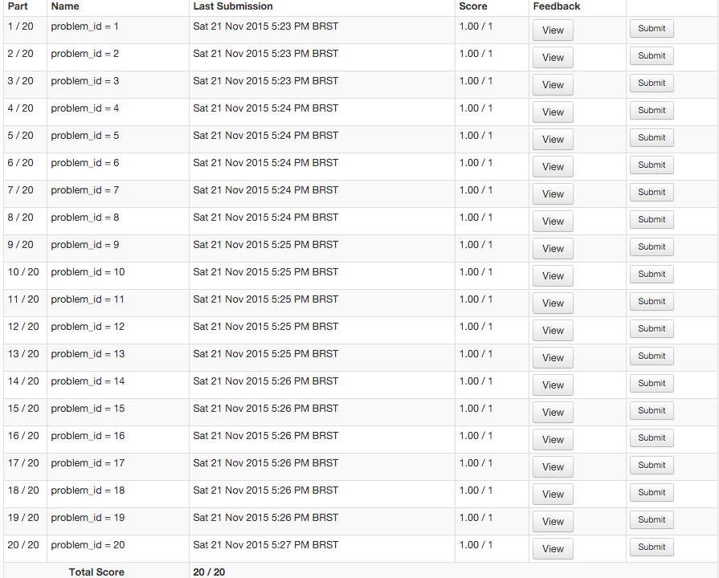